# Import Library

```python
import pandas as pd
import numpy as np
import matplotlib.pyplot as plt
import seaborn as sns
from sklearn.preprocessing import StandardScaler
from sklearn.cluster import KMeans
from sklearn.metrics import silhouette_score
from pyclustering.cluster.kmedoids import kmedoids
from pyclustering.cluster.kmedians import kmedians
from sklearn.cluster import kmeans_plusplus
from scipy import stats
from sklearn.decomposition import PCA
from sklearn.preprocessing import PowerTransformer
from sklearn.cluster import AgglomerativeClustering
from IPython.display import display, Math, Latex
from fcmeans import FCM
import contextily as ctx
```

```python
# import data
df = pd.read_excel('C:/Users/Dzulfahmi DA/OneDrive - UGM 365/02. [UGM]/00. Compt/14. Gelar Rasa/Study Case DSC/fraud.xlsx')
df.head()
```

|  | trans_date_trans_time | merchant | category | amt | city | state | lat | long | city_pop | job | dob | trans_num | merch_lat | merch_long | is_fraud |
| --- | --- | --- | --- | --- | --- | --- | --- | --- | --- | --- | --- | --- | --- | --- | --- |
| 0 | 2019-04-01 00:58:00 | "Stokes, Christiansen and Sipes" | grocery_net | 14.37 | Wales | AK | 64.7556 | -165.6723 | 145 | "Administrator, education" | 1939-09-11 00:00:00 | a3806e984cec6ac0096d8184c64ad3a1 | 65.654142 | -164.722603 | 1 |
| 1 | 2019-04-01 15:06:00 | Predovic Inc | shopping_net | 966.11 | Wales | AK | 64.7556 | -165.6723 | 145 | "Administrator, education" | 1939-09-11 00:00:00 | a59185fe1b9ccf21323f581d7477573f | 65.468863 | -165.473127 | 1 |
| 2 | 2019-04-01 22:37:00 | Wisozk and Sons | misc_pos | 49.61 | Wales | AK | 64.7556 | -165.6723 | 145 | "Administrator, education" | 1939-09-11 00:00:00 | 86ba3a888b42cd3925881fa34177b4e0 | 65.347667 | -165.914542 | 1 |
| 3 | 2019-04-01 23:06:00 | Murray-Smitham | grocery_pos | 295.26 | Wales | AK | 64.7556 | -165.6723 | 145 | "Administrator, education" | 1939-09-11 00:00:00 | 3a068fe1d856f0ecedbed33e4b5f4496 | 64.445035 | -166.080207 | 1 |
| 4 | 2019-04-01 23:59:00 | Friesen Lt | health_fitness | 18.17 | Wales | AK | 64.7556 | -165.6723 | 145 | "Administrator, education" | 1939-09-11 00:00:00 | 891cdd1191028759dc20dc224347a0ff | 65.447094 | -165.446843 | 1 |

# BAGIAN B

## Permasalahan 2

### 1. Pendahuluan

**Tujuan dan Ruang Lingkup Analisis:**

- Dalam analisis ini, akan dibangun model *clustering* untuk mengelompokkan data ke dalam tiga *cluster*. Model ini akan didasarkan pada variabel-variabel:
  - **amt**: jumlah transaksi,
  - **lat**: lintang lokasi pembelian,
  - **long**: bujur lokasi pembelian,
  - **city_pop**: populasi kota pemegang kartu kredit,
  - **merch_lat**: garis lintang lokasi pedagang, dan
  - **merch_long**: garis bujur lokasi pedagang.
- Berdasarkan *cluster* yang terbentuk, akan diidentifikasi tiap *cluster* untuk memberikan rekomendasi kepada perusahaan untuk meningkatkan jumlah pelanggan Loans 'R Us.

### 2. Metodologi

**A. Konsep Clustering dalam Data Mining**

Menurut James, et al (2023), *clustering* merupakan suatu teknik untuk menemukan subkelompok atau klaster dalam suatu *dataset*. Ketika dilakukan pengklasteran pada observasi-observasi dalam suatu *dataset*, dilakukan pembentukan partisi-partisi observasi yang dimiliki menjadi beberapa kelompok yang berbeda sehingga:

- karakteristik observasi-observasi dalam satu kelompok mirip dan
- karakteristik observasi-observasi antarkelompok berbeda.

Dalam konteks bisnis, *clustering* banyak digunakan untuk segmentasi pelanggan, yaitu pengelompokkan pelanggan berdasarkan karakteristik yang dimiliki. Dalam konteks keamanan, khususnya *fraud detection*, *clustering* dapat digunakan untuk mendeteksi pola transaksi yang tidak biasa.

**B. Teknik Clustering yang Digunakan**

Klaster yang baik akan memiliki homogenitas yang tinggi antaranggota klaster dan heterogenitas yang tinggi antarklaster yang satu dengan klaster yang lain.

Secara umum, proses analisis *cluster* adalah sebagai berikut.

1. **Mengukur Kesamaan Antarobjek (*Similarity Measure*)**

   Pada data metrik, kesamaan objek diukur menggunakan korelasi dan jarak (*distance*). Pengukuran jarak yang sering digunakan adalah metode Euclidean Distance. Pada data non-metrik, kesamaan objek diukur menggunakan asosiasi antarobjek.
2. **Membuat Klaster**

   Terdapat beberapa metode pembentukan klaster, yaitu *partitioning*, *hierarchical*, dan *density-based.
   - *Hierarchical Clustering* adalah metode yang membangun struktur hirarki dalam bentuk pohon. Metode ini dimulai dengan mengelompokkan dari dua atau lebih objek yang memiliki kesamaan paling dekat. Kemudian, proses diteruskan kepada objek lain yang mempunyai kedekatan kedua. Proses ini dilakukan secara terus menerus. Algoritma *hierarchical clustering* yang populer adalah *Agglomerative* dan *Divisive*.
   - *Partitional Clustering* adalah metode partisi data secara berulang-ulang hingga menjadi beberapa klaster. Pada prinsipnya, partisi dicapai melalui meminimalkan jumlah kuadarat jarak di setiap klaster. Beberapa algoritma *partitional clustering* yang populer adalah *K-means*, *K-medoids*, dan *K-Modes*.
   - *Density-based Clustering* adalah metode yang mengelompokkan data berdasarkan kerapatan data. Salah satu algoritma *density-based clustering* yang populer adalah *DBSCAN*.
3. **Interpretasi terhadap Klaster yang Terbentuk**

   Interpretasi dilakukan dengan melihat karakteristik klaster yang terbentuk. Karakteristik klaster dapat dilihat dari nilai rata-rata, modus, median, dan sebagainya.
4. **Validasi dan *Profiling* Klaster**

   Klaster yang terbentuk akan diuji apakah sudah baik atau belum. Uji ini dapat dilakukan dengan melihat nilai *silhouette coefficient*.

   Setelah dilakukan validasi, klaster juga akan di-*profile* untuk melihat karakteristik tiap klaster yang terbentuk berdasarkan profil tertentu.

**C. Evaluasi Clustering**

Pada analisis ini, evaluasi *clustering* dilakukan dengan menggunakan *silhouette coefficient*. *Silhouette coefficient* atau skor siluet adalah metrik yang digunakan untuk mengevaluasi seberapa baik hasil *clustering* yang dilakukan oleh suatu model. Skor ini mengukur kedekatan antara data dalam satu klaster dan seberapa jauh data tersebut dari klaster lain. Skor siluet untuk titik data $i$ diberikan sebagai $$s_i = \frac{b_i - a_i}{\max(a_i, b_i)}$$ dengan

- $a_i$ adalah jarak intraklaster yang didefinisikan sebagai jarak rata-rata titik data $i$ ke semua titik lain dalam klaster titik data $i$ berada. $a_i$ dirumuskan sebagai: $$a_i = \frac{1}{|C_i| - 1} \sum_{j \in C_i, i \neq j} d(i, j)$$
- $b_i$ adalah jarak antarklaster yang didefinisikan sebagai jarak rata-rata ke klaster terdekat dari titik data $i$ kecuali itu adalah bagian darinya. $b_i$ dirumuskan sebagai: $$b_i = \min_{k \neq i} \frac{1}{|C_k|} \sum_{j \in C_k} d(i, j)$$ Skor siluet keseluruhan untuk data lengkap dapat dihitung sebagai rata-rata skor siluet untuk semua titik data dalam kumpulan data. Berdasarkan rumus skor siluet, skor siluet selalu bernilai dalam rentang [-1, 1]. Semakin tinggi skor siluet, semakin baik model *clustering* yang dihasilkan.

### 3. Pemodelan

##### **A. Eksplorasi Data**

Dari data yang ada, akan dilakukan eksplorasi data untuk melihat karakteristik data yang ada. Eksplorasi data dilakukan dengan melihat statistik deskriptif, distribusi data, dan sebagainya. Variabel dipilih berdasarkan *study case* yang ada, yaitu *amt*, *lat*, *long*, *city_pop*, *merch_lat*, dan *merch_long*.

```python
# Memilih subset data yang akan digunakan
data_clustering = df[['amt', 'lat', 'long', 'city_pop', 'merch_lat', 'merch_long']]
data_clustering.head()
```

|  | amt | lat | long | city_pop | merch_lat | merch_long |
| --- | --- | --- | --- | --- | --- | --- |
| 0 | 14.37 | 64.7556 | -165.6723 | 145 | 65.654142 | -164.722603 |
| 1 | 966.11 | 64.7556 | -165.6723 | 145 | 65.468863 | -165.473127 |
| 2 | 49.61 | 64.7556 | -165.6723 | 145 | 65.347667 | -165.914542 |
| 3 | 295.26 | 64.7556 | -165.6723 | 145 | 64.445035 | -166.080207 |
| 4 | 18.17 | 64.7556 | -165.6723 | 145 | 65.447094 | -165.446843 |

**Pengecekan *missing value***

```python
# Mengecek apakah ada missing value
data_clustering.isnull().sum()
```

```
amt           0
lat           0
long          0
city_pop      0
merch_lat     0
merch_long    0
dtype: int64
```

Dari hasil pengecekan, tidak ditemukan *missing value* pada data.

**Statistik Deskriptif Data**

```python
# Summary statistics
data_clustering.describe()
```

|  | amt | lat | long | city_pop | merch_lat | merch_long |
| --- | --- | --- | --- | --- | --- | --- |
| count | 14446.000000 | 14446.000000 | 14446.000000 | 1.444600e+04 | 14446.000000 | 14446.000000 |
| mean | 124.430073 | 39.787692 | -110.874225 | 1.065370e+05 | 39.787991 | -110.874892 |
| std | 231.352587 | 5.317039 | 12.985813 | 2.902916e+05 | 5.360593 | 12.995596 |
| min | 1.000000 | 20.027100 | -165.672300 | 4.600000e+01 | 19.032689 | -166.670685 |
| 25% | 12.080000 | 36.715400 | -120.415800 | 4.930000e+02 | 36.794655 | -120.146253 |
| 50% | 51.520000 | 39.666200 | -111.098500 | 1.645000e+03 | 39.620953 | -111.192629 |
| 75% | 101.030000 | 41.940400 | -101.136000 | 3.543900e+04 | 42.275740 | -100.446822 |
| max | 3261.470000 | 66.693300 | -89.628700 | 2.383912e+06 | 67.510267 | -88.646366 |

Keluaran di atas adalah statistik deskriptif dari data yang ada. Dari statistik deskriptif, dapat dilihat bahwa data memiliki rentang nilai yang cukup bervariasi.

**Visualisasi Sebaran Data**

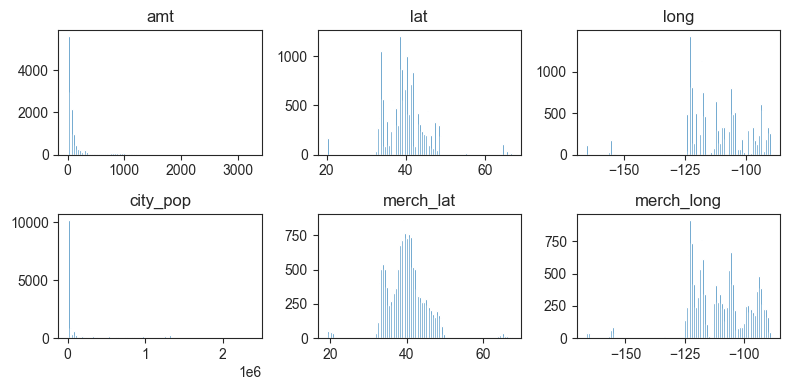

```python
# Menggunakan 3 kolom dan menyesuaikan jumlah baris
fig, ax = plt.subplots(2, 3, figsize=(8, 4))  # 2 baris, 3 kolom

for i in range(2):  # 2 baris
    for j in range(3):  # 3 kolom
        ax[i, j].hist(data_clustering.iloc[:, i*3+j], bins=100)
        ax[i, j].set_title(data_clustering.columns[i*3+j])

plt.tight_layout()  # Agar jarak antar subplots rapat
plt.show()
```

Keluaran di atas adalah visualisasi sebaran data klaster. Dari visualisasi, dapat dilihat bahwa data memiliki sebaran yang cukup bervariasi sesuai dengan statistik deskriptif sebelumnya. Beberapa variabel cenderung memiliki sebaran yang lebih padat di beberapa titik tertentu.

**Cek Pencilan**

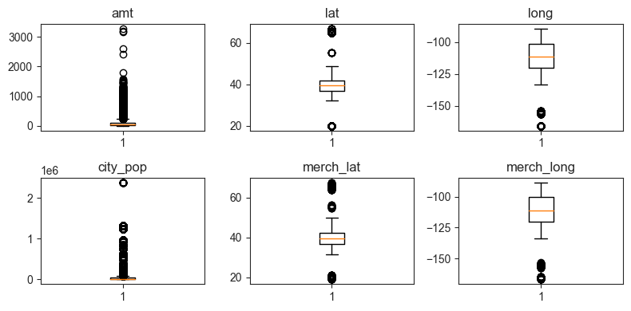

```python
# Membuat Boxplot
fig, ax = plt.subplots(2, 3, figsize=(8, 4))  # 2 baris, 3 kolom

for i in range(2):  # 2 baris
    for j in range(3):  # 3 kolom
        ax[i, j].boxplot(data_clustering.iloc[:, i*3+j])
        ax[i, j].set_title(data_clustering.columns[i*3+j])

plt.tight_layout()  # Agar jarak antar subplots rapat
plt.show()
```

Keluaran di atas adalah boxplot dari data yang ada. Boxplot atau diagram kotak-sempang digunakan untuk melihat sebaran data. Dari boxplot, dapat dilihat bahwa data memiliki outlier pada semua variabel.

**Cek Hubungan AntarVariabel**

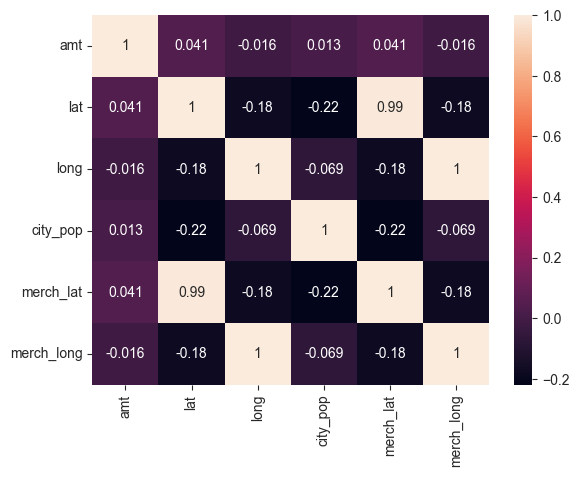

```python
# Correlation Plot
sns.heatmap(data_clustering.corr(), annot=True)
plt.figure(figsize=(5, 5))
plt.show()
```

Keluaran di atas adalah *heatmap* korelasi antarvariabel. *Heatmap* dapat digunakan untuk melihat hubungan antarvariabel. Dari *heatmap* di atas, dapat dilihat bahwa hanya variabel `lat` dan `long` yang memiliki korelasi yang cukup tinggi dengan variabel `merch_lat` dan `merch_long`. Variabel lainnya memiliki korelasi yang rendah.

**Cek Hubungan Linear Data**

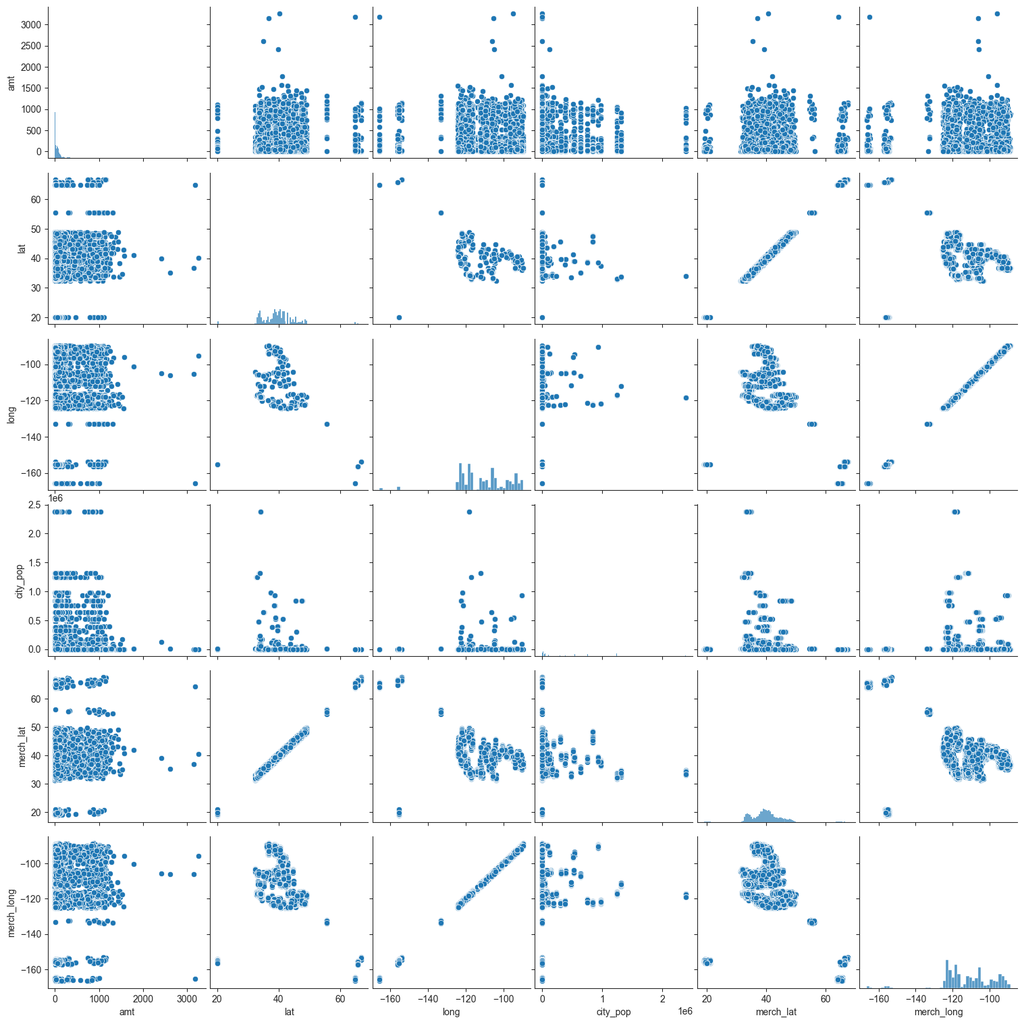

```python
# Plot Scatter Plot Matrix
plt.figure(figsize=(5, 5))
sns.pairplot(data_clustering)
plt.tight_layout(pad=0.1)
plt.show()
```

Keluaran di atas adalah *scatter plot* antarvariabel. *Scatter plot* digunakan untuk melihat apakah ada hubungan linear antarvariabel atau tidak. Dari *scatter plot* di atas, dapat dilihat bahwa tidak ada hubungan linear yang kuat antarvariabel, kecuali antara `lat` dan `merch_lat`, serta `long` dan `merch_long`. Variabel lainnya tidak memiliki hubungan linear yang kuat, bahkan memiliki pola yang acak. Dari visualisasi ini, dapat dilihat juga bahwa transaksi dengan total jumlah tertentu memiliki sebaran tertentu di beberapa titik.

##### **B. Prepocessing Data**

Preprocessing data dilakukan untuk mempersiapkan data sebelum pemodelan. Salah satu langkah penting dalam proses ini adalah menangani outlier, yang dapat memengaruhi kualitas dan akurasi model. Dalam analisis ini, outlier akan diatasi dengan menggunakan metode RobustScaler. Metode ini dipilih karena RobustScaler dirancang untuk menangani outlier dengan lebih baik dibandingkan metode lain, seperti winsorization atau clipping.

**Transformasi Robust Scaler**

RobustScaler adalah metode metode penskalaan berbasis median. Rumus dari RobustScaler adalah

$$X_{new}= \frac{X - X_{median}}{IQR}$$

sehingga tidak terpengaruh oleh pencilan. Karena menggunakan rentang interkuartil, rentang ini menyerap efek outlier saat melakukan penskalaan. Rentang interkuartil $Q_3-Q_1$ memiliki setengah titik data.

Pada analisis ini, RobustScaler digunakan untuk hanya untuk variabel `city_pop` dan `amt` dengan didasarkan pada beberapa pertimbangan logis. Berdasarkan hasil eksplorasi dan visualisasi sebelumnya, kedua variabel tersebut memiliki rentang nilai yang cukup besar dibandingkan dengan variabel geografis, seperti `lat`, `long`, `merch_lat`, dan `merch_long`, yang mana memiliki skala terbatas. Koordinat Geografis memiliki makna intriksik yang penting dalam konteks analisis ini.

```python
# Memisahkan kolom yang akan di-scale
columns_to_scale = ['amt', 'city_pop']
columns_no_scale = [col for col in data_clustering.columns if col not in columns_to_scale]

# Inisialisasi dan fit RobustScaler
robust_scaler = RobustScaler()

# Transformasi hanya untuk amt dan city_pop
scaled_data = robust_scaler.fit_transform(data_clustering[columns_to_scale])

# Membuat DataFrame baru dengan hasil scaling
data_clustering_robust = pd.DataFrame(scaled_data, columns=columns_to_scale)

# Membuat DataFrame baru setelah penggabungan data
data_clustering_robust= pd.concat([data_clustering_robust, data_clustering[columns_no_scale].reset_index(drop=True)], axis=1)
```

Variabel `data_clustering_robust` adalah data yang sudah di-*transform* menggunakan RobustScaler. Variabel ini akan digunakan dalam pemodelan selanjutnya.

```python
data_clustering_robust.describe()
```

[output not shown]

##### **C. Pemodelan**

Pada analisis ini, digunakan beberapa pemodelan dari jenis metode *clustering* yang ada.

```python
random_state_custom = 42 # Untuk reproducibility atau reproduksi hasil yang sama sehingga mudah untuk diuji ulang
```

**K-Means Clustering**

```python
kmeans = KMeans(n_clusters=3, random_state=random_state_custom) # Digunakan n_clusters=3 karena akan dibagi menjadi 3 cluster
y_pred_kmeans = kmeans.fit_predict(data_clustering_robust) # Fitting dan Predicting
ss_kmeans = silhouette_score(data_clustering_robust, y_pred_kmeans) # Menghitung Silhouette Score
print(f"Silhouette Score KMeans dengan data yang sudah di-transformasi: {ss_kmeans}")
```

```
Silhouette Score KMeans dengan data yang sudah di-transformasi: 0.4894914960899288
```

**K-Medoids Clustering**

```python
# Set random seed untuk memastikan hasil yang konsisten
np.random.seed(random_state_custom)

# Menentukan centroid awal secara manual (misalnya, mengambil 3 titik acak sebagai centroid awal)
initial_centroids = np.random.choice(data_clustering_robust.shape[0], size=3, replace=False)

# Menjalankan K-medoids
k_medoids = kmedoids(data_clustering_robust.values, initial_centroids)
k_medoids.process()

# Mendapatkan label hasil klaster
labels = k_medoids.get_clusters()

# Membuat label yang sesuai dengan format yang dibutuhkan untuk silhouette score
label_array = np.zeros(data_clustering_robust.shape[0], dtype=int)
for cluster_id, cluster in enumerate(labels):
    label_array[cluster] = cluster_id + 1  # Mulai dari 1 agar label berbeda dengan 0

# Menghitung silhouette score
sil_score_kmedoid = silhouette_score(data_clustering_robust, label_array)

# Menampilkan hasil silhouette score
print(f"Silhouette Score K-Medoids dengan data yang sudah di-transformasi: {sil_score_kmedoid}")
```

```
Silhouette Score K-Medoids dengan data yang sudah di-transformasi: 0.3847128600851407
```

**K-Median Clustering**

```python
# Menentukan centroid awal menggunakan kmeans_plusplus
initial_centroids = kmeans_plusplus(data_clustering_robust.values, n_clusters=3, random_state=random_state_custom)[0]

# Menjalankan K-medians dari pyclustering
k_median = kmedians(data_clustering_robust.values, initial_centroids)
k_median.process()

# Mendapatkan hasil klaster
clusters = k_median.get_clusters()

# Membuat array label untuk klaster
labels = np.zeros(data_clustering_robust.shape[0], dtype=int)

# Mengisi array label berdasarkan indeks klaster
for cluster_id, cluster in enumerate(clusters):
    labels[cluster] = cluster_id

# Menghitung silhouette score
sil_score_kmedian = silhouette_score(data_clustering_robust, labels)

print(f"Silhouette Score K-Medians dengan data yang sudah di-transformasi: {sil_score_kmedian}")
```

```
Silhouette Score K-Medians dengan data yang sudah di-transformasi: 0.46857338228942597
```

**Agglomerative Clustering**

```python
AC = AgglomerativeClustering(n_clusters=3)
y_pred_ac = AC.fit_predict(data_clustering_robust)
data_clustering_robust['cluster'] = y_pred_ac

ss_ac = silhouette_score(data_clustering_robust, y_pred_ac)
print(f"Silhouette Score Agglomerative Clustering dengan data yang sudah ditransformasi Robust Scaler: {ss_ac}")
```

```
Silhouette Score Agglomerative Clustering dengan data yang sudah ditransformasi Robust Scaler: 0.4775442185055166
```

**Fuzzy C-Means Clustering**

```python
n_clusters = 3

fcm = FCM(n_clusters=n_clusters)
fcm.fit(data_clustering_robust.values)

labels = fcm.predict(data_clustering_robust.values)

# Menghitung silhouette score
ss_fcm = silhouette_score(data_clustering_robust, labels)
print(f"Silhouette Score Fuzzy C-Means dengan data yang sudah di-transformasi: {ss_fcm}")
```

```
Silhouette Score Fuzzy C-Means dengan data yang sudah di-transformasi: 0.37971365045495936
```

**Robust Weighted K-Means Clustering**

```python
from sklearn_extra.robust import RobustWeightedKMeans

rwkmeans = RobustWeightedKMeans(n_clusters=3, random_state=random_state_custom)

y_pred_rwkmeans = rwkmeans.fit(data_clustering_robust)

# Label hasil klaster
labels_rwkmeans = rwkmeans.labels_

# Menghitung silhouette score
ss_rwkmeans = silhouette_score(data_clustering_robust, labels_rwkmeans)

print(f"Silhouette Score Robust Weighted K-Means dengan data hasil Robust Scaler: {ss_rwkmeans}")
```

```
Silhouette Score Robust Weighted K-Means dengan data hasil Robust Scaler: 0.48618059675067604
```

**K-Means ++ Clustering**

```python
from sklearn.cluster import KMeans

# Menyiapkan model KMeans++ dengan 3 klaster
kmeans = KMeans(n_clusters=3, init='k-means++', random_state=random_state_custom)
labels_kmeans = kmeans.fit_predict(data_clustering_robust)

# Silhouette score
ss_kmeansplusplus = silhouette_score(data_clustering_robust, labels_kmeans)
print(f"Silhouette Score KMeans++ dengan data hasil Robust Scaler: {ss_kmeansplusplus}")
```

```
Silhouette Score KMeans++ dengan data hasil Robust Scaler: 0.48960349864107405
```

**Gaussian Mixture Model Clustering**

```python
from sklearn.mixture import GaussianMixture

# Menyiapkan model GMM
gmm = GaussianMixture(n_components=3, random_state=random_state_custom)
labels_gmm = gmm.fit_predict(data_clustering_robust)

# silhouette score
ss_gmm = silhouette_score(data_clustering_robust, labels_gmm)
print(f"Silhouette Score Gaussian Mixture Model dengan data hasil Robust Scaler: {ss_gmm}")
```

```
Silhouette Score Gaussian Mixture Model dengan data hasil Robust Scaler: 0.13130484960160183
```

**Spectral Co Clustering**

```python
from sklearn.cluster import SpectralCoclustering

# Menyiapkan model Co-Clustering
model = SpectralCoclustering(n_clusters=3, random_state=random_state_custom)
model.fit(data_clustering_robust)

# Menghitung silhouette score
ss_coclustering = silhouette_score(data_clustering_robust, model.row_labels_)
print(f"Silhouette Score Co-Clustering dengan data hasil Robust Scaler: {ss_coclustering}")
```

```
Silhouette Score Co-Clustering dengan data hasil Robust Scaler: 0.4860087550387818
```

**Isolation Forest Clustering**

```python
from sklearn.ensemble import IsolationForest

# Menyiapkan model Isolation Forest
isolation_forest = IsolationForest(n_estimators=100, random_state=random_state_custom)
labels_isolation_forest = isolation_forest.fit_predict(data_clustering_robust)

# Silhouette score
ss_isolation_forest = silhouette_score(data_clustering_robust, labels_isolation_forest)
print(f"Silhouette Score Isolation Forest dengan data hasil Robust Scaler: {ss_isolation_forest}")
```

```
Silhouette Score Isolation Forest dengan data hasil Robust Scaler: 0.3884324807873884
```

**Deep Clustering: Model Autoencoder dengan K-Mean Clustering**

Autoencoder adalah jenis jaringan saraf yang digunakan untuk belajar representasi yang efisien dari data input, biasanya dengan cara mengurangi dimensi data tersebut. Model ini terdiri dari dua bagian utama: encoder dan decoder. Encoder bertugas untuk mengompresi data input menjadi representasi yang lebih kecil, sementara decoder berfungsi untuk merekonstruksi data asli dari representasi tersebut.

```python
from keras.models import Model
from keras.layers import Input, Dense
from sklearn.cluster import KMeans

# Membuat autoencoder
input_dim = data_clustering_robust.shape[1]
input_layer = Input(shape=(input_dim,))
encoded = Dense(64, activation='relu')(input_layer)
decoded = Dense(input_dim, activation='sigmoid')(encoded)

autoencoder = Model(input_layer, decoded)
encoder = Model(input_layer, encoded)

autoencoder.compile(optimizer='adam', loss='mean_squared_error')
autoencoder.fit(data_clustering_robust, data_clustering_robust, epochs=100)

# Menggunakan encoder untuk mendapatkan representasi yang lebih kecil
encoded_data = encoder.predict(data_clustering_robust)

# Lakukan KMeans pada representasi terkompresi
kmeans = KMeans(n_clusters=3, random_state=random_state_custom)
labels_deep_clustering = kmeans.fit_predict(encoded_data)

# Menghitung silhouette score
ss_deep_clustering_cluster3 = silhouette_score(data_clustering_robust, labels_deep_clustering)
print(f"Silhouette Score Deep Clustering dengan data hasil Robust Scaler: {ss_deep_clustering}")
```

[output not shown]

[output cut: 47 more lines]

[output not shown]

Pada analisis ini, dilakukan hyperparameter tuning pada model Deep Clustering dengan Autoencoder dan K-Means Clustering. Hyperparameter tuning dilakukan dengan mencari kombinasi hyperparameter yang optimal untuk meningkatkan performa model. Cluster akan ditentukan sendiri oleh Deep Clustering berikut.

```python
from keras.models import Model
from keras.layers import Input, Dense
from sklearn.cluster import KMeans
from sklearn.metrics import silhouette_score
import numpy as np

# Fungsi untuk membuat dan melatih autoencoder
def create_autoencoder(input_dim, encoding_dim):
    input_layer = Input(shape=(input_dim,))
    encoded = Dense(encoding_dim, activation='relu')(input_layer)
    decoded = Dense(input_dim, activation='sigmoid')(encoded)

    autoencoder = Model(input_layer, decoded)
    encoder = Model(input_layer, encoded)

    autoencoder.compile(optimizer='adam', loss='mean_squared_error')
    return autoencoder, encoder

# Hyperparameter tuning
encoding_dims = [32, 64, 128]  # Dimensi encoding yang berbeda
epochs_list = [50, 100, 200]     # Jumlah epoch yang berbeda
n_clusters_list = [2, 3, 4, 5]   # Jumlah cluster yang berbeda

best_score = -1
best_params = {}

# Loop untuk melakukan tuning hyperparameter
for encoding_dim in encoding_dims:
    for epochs in epochs_list:
        # Membuat dan melatih autoencoder
        autoencoder, encoder = create_autoencoder(data_clustering_robust.shape[1], encoding_dim)
        autoencoder.fit(data_clustering_robust, data_clustering_robust, epochs=epochs, verbose=0)

        # Mendapatkan representasi yang lebih kecil
        encoded_data = encoder.predict(data_clustering_robust)

        for n_clusters in n_clusters_list:
            # Melakukan KMeans pada representasi terkompresi
            kmeans = KMeans(n_clusters=n_clusters, random_state=random_state_custom)
            labels_deep_clustering = kmeans.fit_predict(encoded_data)

            # Menghitung silhouette score
            ss_deep_clustering = silhouette_score(data_clustering_robust, labels_deep_clustering)
            print(f"Silhouette Score untuk encoding_dim={encoding_dim}, epochs={epochs}, n_clusters={n_clusters}: {ss_deep_clustering}")

            # Menyimpan parameter terbaik
            if ss_deep_clustering > best_score:
                best_score = ss_deep_clustering
                best_params = {
                    'encoding_dim': encoding_dim,
                    'epochs': epochs,
                    'n_clusters': n_clusters
                }

print(f"Parameter terbaik: {best_params} dengan Silhouette Score: {best_score}")
```

```
452/452 ━━━━━━━━━━━━━━━━━━━━ 0s 869us/step
Silhouette Score untuk encoding_dim=32, epochs=50, n_clusters=2: 0.4481226865238378
Silhouette Score untuk encoding_dim=32, epochs=50, n_clusters=3: 0.45968989237071745
Silhouette Score untuk encoding_dim=32, epochs=50, n_clusters=4: 0.39903974426974925
Silhouette Score untuk encoding_dim=32, epochs=50, n_clusters=5: 0.4104665651495947
452/452 ━━━━━━━━━━━━━━━━━━━━ 1s 2ms/step
Silhouette Score untuk encoding_dim=32, epochs=100, n_clusters=2: 0.30207670202840875
Silhouette Score untuk encoding_dim=32, epochs=100, n_clusters=3: 0.45113880180341476
Silhouette Score untuk encoding_dim=32, epochs=100, n_clusters=4: 0.3603241758790265
Silhouette Score untuk encoding_dim=32, epochs=100, n_clusters=5: 0.3716685969219719
452/452 ━━━━━━━━━━━━━━━━━━━━ 0s 563us/step
Silhouette Score untuk encoding_dim=32, epochs=200, n_clusters=2: 0.24525209428399422
Silhouette Score untuk encoding_dim=32, epochs=200, n_clusters=3: 0.1522750532866672
Silhouette Score untuk encoding_dim=32, epochs=200, n_clusters=4: 0.12420681294551619
Silhouette Score untuk encoding_dim=32, epochs=200, n_clusters=5: 0.2507809050549563
452/452 ━━━━━━━━━━━━━━━━━━━━ 0s 599us/step
Silhouette Score untuk encoding_dim=64, epochs=50, n_clusters=2: 0.463660314394152
Silhouette Score untuk encoding_dim=64, epochs=50, n_clusters=3: 0.4698855031112405
Silhouette Score untuk encoding_dim=64, epochs=50, n_clusters=4: 0.5033167041099587
Silhouette Score untuk encoding_dim=64, epochs=50, n_clusters=5: 0.4500465805904035
452/452 ━━━━━━━━━━━━━━━━━━━━ 0s 648us/step
Silhouette Score untuk encoding_dim=64, epochs=100, n_clusters=2: 0.13076449052077327
Silhouette Score untuk encoding_dim=64, epochs=100, n_clusters=3: 0.3550741335445696
Silhouette Score untuk encoding_dim=64, epochs=100, n_clusters=4: 0.40827607507240427
Silhouette Score untuk encoding_dim=64, epochs=100, n_clusters=5: 0.27542531613337545
452/452 ━━━━━━━━━━━━━━━━━━━━ 0s 624us/step
Silhouette Score untuk encoding_dim=64, epochs=200, n_clusters=2: 0.6874943495228419
Silhouette Score untuk encoding_dim=64, epochs=200, n_clusters=3: 0.47429638483591396
Silhouette Score untuk encoding_dim=64, epochs=200, n_clusters=4: 0.518776521463056
Silhouette Score untuk encoding_dim=64, epochs=200, n_clusters=5: 0.528989558162548
452/452 ━━━━━━━━━━━━━━━━━━━━ 0s 686us/step
Silhouette Score untuk encoding_dim=128, epochs=50, n_clusters=2: 0.4575964517476664
Silhouette Score untuk encoding_dim=128, epochs=50, n_clusters=3: 0.3575172484332511
Silhouette Score untuk encoding_dim=128, epochs=50, n_clusters=4: 0.39995054548434106
Silhouette Score untuk encoding_dim=128, epochs=50, n_clusters=5: 0.41929409679862273
452/452 ━━━━━━━━━━━━━━━━━━━━ 0s 591us/step
Silhouette Score untuk encoding_dim=128, epochs=100, n_clusters=2: 0.4571967384056155
Silhouette Score untuk encoding_dim=128, epochs=100, n_clusters=3: 0.3539902340773603
Silhouette Score untuk encoding_dim=128, epochs=100, n_clusters=4: 0.40129713597749433
Silhouette Score untuk encoding_dim=128, epochs=100, n_clusters=5: 0.3966413846980337
452/452 ━━━━━━━━━━━━━━━━━━━━ 0s 572us/step
Silhouette Score untuk encoding_dim=128, epochs=200, n_clusters=2: 0.4608281403240548
Silhouette Score untuk encoding_dim=128, epochs=200, n_clusters=3: 0.38211063600428125
Silhouette Score untuk encoding_dim=128, epochs=200, n_clusters=4: 0.3944801595712812
Silhouette Score untuk encoding_dim=128, epochs=200, n_clusters=5: 0.46606655226101773
Parameter terbaik: {'encoding_dim': 64, 'epochs': 200, 'n_clusters': 2} dengan Silhouette Score: 0.6874943495228419
```

Keluaran di atas adalah proses pencarian hyperparameter dan ditemukan kombinasi terbaik untuk autoencoder dan KMeans:

- Dimensi Encoding (encoding_dim): 64
- Jumlah Epoch: 200
- Jumlah Cluster: 2
- Silhouette Score Terbaik: 0.6874943495228419

Hasil ini menunjukkan bahwa dengan menggunakan dimensi encoding 64 dan melatih model selama 200 epoch, serta mengelompokkan data ke dalam 2 cluster, model menghasilkan performa terbaik dalam hal pengelompokan data.

Akan tetapi, karena permasalahan yang dihadapi adalah mengelompokkan data ke dalam 3 cluster, maka model ini belum dapat digunakan untuk memberikan rekomendasi kepada perusahaan. Oleh karena itu, perlu dilakukan eksperimen lebih lanjut dengan mencari kombinasi hyperparameter yang optimal untuk mengelompokkan data ke dalam 3 cluster.

**Kesimpulan**

Berikut adalah tabel perbandingan nilai silhouete dari beberapa model *clustering* yang telah dibangun dengan **data yang sudah ditransformasi**.

```python
# Menampilkan tabel silhouette score dari semua metode
methods = ['KMeans', 'KMedoids', 'KMedians', 'Agglomerative Clustering', 'Fuzzy C-Means', 'Robust Weighted K-Means', 'KMeans++', 'Gaussian Mixture Model', 'Co-Clustering', 'Isolation Forest', 'Deep Clustering']
silhouette_scores = [ss_kmeans, sil_score_kmedoid, sil_score_kmedian, ss_ac, ss_fcm, ss_rwkmeans, ss_kmeansplusplus, ss_gmm, ss_coclustering, ss_isolation_forest, ss_deep_clustering_cluster3]

silhouette_scores_df = pd.DataFrame({'Method': methods, 'Silhouette Score': silhouette_scores})

# Menampilkan tabel silhouette score dengan siluet yang terurut dari yang tertinggi
silhouette_scores_df.sort_values(by='Silhouette Score', ascending=False)
```

|  | Method | Silhouette Score |
| --- | --- | --- |
| 6 | KMeans++ | 0.489603 |
| 0 | KMeans | 0.489491 |
| 5 | Robust Weighted K-Means | 0.486181 |
| 8 | Co-Clustering | 0.486009 |
| 3 | Agglomerative Clustering | 0.477544 |
| 10 | Deep Clustering | 0.470624 |
| 2 | KMedians | 0.468573 |
| 9 | Isolation Forest | 0.388432 |
| 1 | KMedoids | 0.384713 |
| 4 | Fuzzy C-Means | 0.379714 |
| 7 | Gaussian Mixture Model | 0.131305 |

### 4. Analisis Hasil Clustering dan Karakteristik Klaster

**Asumsi Model**

Setelah dilakukan analisis *clustering*, akan dilakukan analisis hasil *clustering* dan karakteristik klaster yang terbentuk. Pada langkah ini, akan dilakukan interpretasi terhadap klaster yang terbentuk. Interpretasi dilakukan dengan melihat karakteristik klaster yang terbentuk berdasarkan profil tertentu.

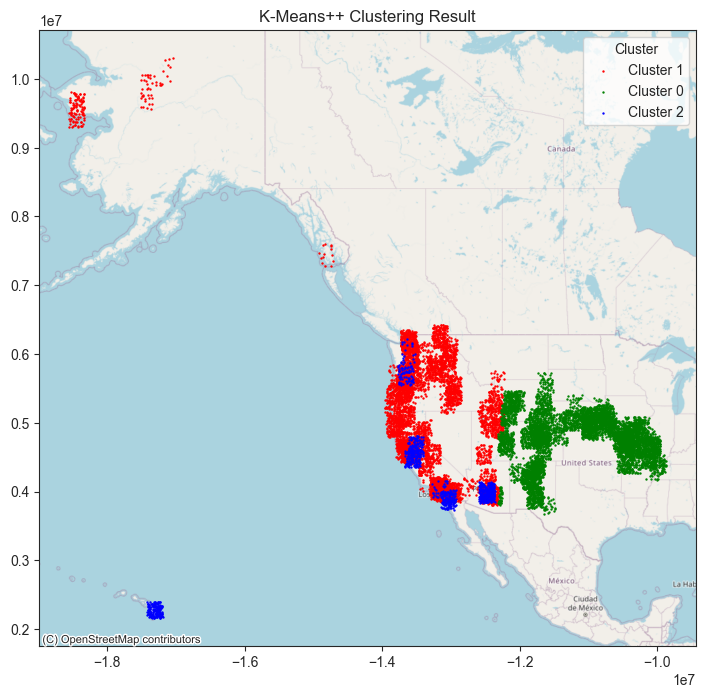

```python
import numpy as np
import geopandas as gpd
import matplotlib.pyplot as plt
import contextily as ctx
from sklearn.cluster import KMeans
from shapely.geometry import Point

# Menggunakan KMeans++ untuk inisialisasi centroid
kmeansplusplus = KMeans(n_clusters=3, init='k-means++', random_state=random_state_custom)

# Melakukan fit pada data untuk mendapatkan klaster
kmeansplusplus.fit(data_clustering_robust)  # data_clustering_robust adalah dataset yang digunakan

# Mendapatkan cluster labels
labels = kmeansplusplus.labels_

# Membuat label untuk cluster secara otomatis
data_clustering_kmeansplusplus = data_clustering.copy()  # Menggunakan nama variabel yang sesuai
data_clustering_kmeansplusplus['cluster'] = labels

# Membuat GeoDataFrame dari data hasil clustering
data_clustering_kmeansplusplus['geometry'] = gpd.points_from_xy(data_clustering_kmeansplusplus['merch_long'], data_clustering_kmeansplusplus['merch_lat'])
gdf = gpd.GeoDataFrame(data_clustering_kmeansplusplus, geometry='geometry', crs='EPSG:4326').to_crs('EPSG:3857')

# Plot hasil clustering pada peta
fig, ax = plt.subplots(figsize=(12, 8))

# Memplot setiap cluster secara terpisah
colors = ['red', 'green', 'blue']  # Warna untuk 3 cluster
for cluster, color in zip(gdf['cluster'].unique(), colors):
    gdf[gdf['cluster'] == cluster].plot(ax=ax, color=color, label=f'Cluster {cluster}', markersize=0.5)

# Menambahkan basemap OpenStreetMap
ctx.add_basemap(ax, crs=gdf.crs, source=ctx.providers.OpenStreetMap.Mapnik)

# Judul dan legenda
plt.title('K-Means++ Clustering Result')
plt.legend(title='Cluster')
plt.show()
```

Gambar di atas menunjukkan hasil clustering menggunakan algoritma K-Means++ yang diterapkan pada data terkait permasalahan *fraud*. Dalam visualisasi ini, terdapat tiga cluster yang berbeda, masing-masing diwakili oleh warna yang berbeda: merah, biru, dan hijau.

```python
summmary_stat = data_clustering_kmeansplusplus.groupby('cluster').describe()

summmary_stat
```

| cluster | amt count | amt mean | amt std | amt min | amt 25% | amt 50% | amt 75% | amt max | lat count | lat mean | ... | merch_lat 75% | merch_lat max | merch_long count | merch_long mean | merch_long std | merch_long min | merch_long 25% | merch_long 50% | merch_long 75% | merch_long max |
| --- | --- | --- | --- | --- | --- | --- | --- | --- | --- | --- | --- | --- | --- | --- | --- | --- | --- | --- | --- | --- | --- |
| 0 | 6870.0 | 122.972319 | 234.518220 | 1.03 | 10.9325 | 51.27 | 96.74 | 3261.47 | 6870.0 | 39.249747 | ... | 40.976956 | 45.652002 | 6870.0 | -100.057268 | 6.328896 | -110.597186 | -105.729365 | -99.387685 | -93.952484 | -88.646366 |
| 1 | 6581.0 | 126.009257 | 228.345463 | 1.00 | 14.0100 | 52.65 | 107.48 | 3178.51 | 6581.0 | 41.310409 | ... | 45.370503 | 67.510267 | 6581.0 | -120.193064 | 7.773010 | -166.670685 | -122.528368 | -119.508350 | -117.251076 | -109.672560 |
| 2 | 995.0 | 124.050342 | 229.259416 | 1.01 | 9.2300 | 44.60 | 97.17 | 1110.42 | 995.0 | 33.430590 | ... | 37.592500 | 48.623846 | 995.0 | -123.934386 | 14.937951 | -156.480766 | -122.415915 | -120.801818 | -112.811947 | -111.056910 |

3 rows × 48 columns

Berdasarkan hasil clustering yang ditunjukkan dalam tabel di atas, kita dapat menganalisis karakteristik masing-masing cluster untuk perusahaan Loans 'R Us dalam konteks mengurangi penipuan kartu kredit.

### 5. Rekomendasi Strategis untuk Perusahaan Loans 'R Us

Berdasarkan analisis cluster yang dilakukan, kami mengidentifikasi tiga kelompok pelanggan dengan karakteristik yang berbeda. Untuk memaksimalkan potensi pertumbuhan dan mengurangi risiko penipuan, berikut adalah rekomendasi strategis yang komprehensif:

1. **Fokus pada Cluster 0 dan Cluster 1**:
   - **Keamanan Transaksi**: Mengingat kedua cluster ini memiliki jumlah transaksi yang tinggi, sangat penting bagi perusahaan untuk meningkatkan program keamanan. Ini dapat mencakup penerapan teknologi deteksi penipuan yang lebih canggih dan pelatihan staf untuk mengenali tanda-tanda penipuan.
   - **Promosi Tertarget**: Penawaran promosi yang menarik bagi pelanggan di area perkotaan, seperti diskon untuk transaksi tertentu atau program cashback, dapat meningkatkan penggunaan kartu kredit. Memanfaatkan data analitik untuk merancang kampanye pemasaran yang lebih efektif juga akan sangat bermanfaat.
2. **Edukasi dan Pemberdayaan Cluster 2**:
   - **Program Edukasi**: Pelanggan dalam cluster ini menunjukkan tingkat penggunaan kartu kredit yang lebih rendah. Oleh karena itu, penting untuk memberikan informasi yang jelas tentang manfaat penggunaan kartu kredit, termasuk program reward dan kemudahan dalam pengelolaan keuangan.
   - **Seminar dan Workshop**: Mengadakan seminar atau workshop tentang pengelolaan keuangan pribadi dan cara memanfaatkan kartu kredit secara optimal dapat membantu meningkatkan pemahaman dan keterlibatan pelanggan. Ini juga dapat membangun kepercayaan dan loyalitas terhadap merek.
3. **Analisis dan Pemantauan Lokasi**:
   - **Identifikasi Area Berisiko**: Memanfaatkan data lokasi untuk mengidentifikasi area dengan potensi tinggi untuk penipuan. Dengan demikian, perusahaan dapat menerapkan langkah-langkah pencegahan yang lebih ketat di wilayah tersebut, seperti verifikasi tambahan untuk transaksi yang mencurigakan.
   - **Strategi Pemasaran Berbasis Lokasi**: Menggunakan analisis lokasi untuk merencanakan strategi pemasaran yang lebih efektif, termasuk penawaran khusus yang disesuaikan dengan demografi dan perilaku pelanggan di masing-masing area.

Dengan menerapkan strategi yang disesuaikan berdasarkan hasil clustering ini, Loans 'R Us tidak hanya dapat mengurangi risiko penipuan tetapi juga meningkatkan jumlah pelanggan secara signifikan. Pendekatan yang holistik ini akan membantu perusahaan untuk tetap kompetitif di pasar kartu kredit dan pinjaman, serta membangun hubungan yang lebih kuat dengan pelanggan.

### 6. Kesimpulan

Analisis clustering yang dilakukan pada data transaksi pelanggan Loans 'R Us menggunakan beberapa metode, dengan K-Means++ sebagai metode yang paling efektif berdasarkan hasil evaluasi. Dengan Silhouette Score tertinggi sebesar 0.489603, K-Means++ menunjukkan kemampuannya dalam mengelompokkan data dengan baik, menghasilkan cluster yang lebih terpisah dan terdefinisi dengan jelas dibandingkan dengan metode lainnya.

Selain pemilihan metode clustering, preprocessing data juga memiliki peranan penting dalam meningkatkan kualitas analisis. Dalam hal ini, penggunaan **RobustScaler** sangat dianjurkan. RobustScaler bekerja dengan mengurangi pengaruh outlier pada data, karena ia menggunakan median dan interquartile range (IQR) untuk menskalakan fitur `amt` dan `city_pop`.

Metode K-Means++ adalah pengembangan dari algoritma K-Means yang bertujuan untuk meningkatkan pemilihan titik pusat (centroid) awal. Dalam K-Means++, pemilihan centroid dilakukan secara acak dengan mempertimbangkan jarak dari titik data yang sudah ada, sehingga mengurangi kemungkinan terjebak dalam solusi lokal yang kurang optimal. Hal ini membuat K-Means++ lebih stabil dan sering kali menghasilkan hasil yang lebih baik dalam hal pemisahan cluster.

**Karakteristik Masing-Masing Cluster**:

**Rekomendasi**: Berdasarkan analisis cluster, perusahaan dapat mengambil langkah-langkah strategis untuk meningkatkan jumlah pelanggan dan mengurangi risiko penipuan. Rekomendasi yang dihasilkan dari karakteristik masing-masing cluster memberikan panduan yang jelas untuk menyesuaikan pendekatan pemasaran dan keamanan sesuai dengan kebutuhan pelanggan. Misalnya, untuk cluster dengan transaksi tinggi, perusahaan dapat meningkatkan program keamanan dan menawarkan promosi menarik. Sementara untuk cluster dengan transaksi rendah, edukasi tentang manfaat penggunaan kartu kredit dapat menjadi strategi yang efektif.